# Class 2

2022-01-24

## Introduction

For this class, we’ll review code examples found in Chapter 2.

This assumes that you have already installed the `rethinking` package.

If you need help, be sure to remember the references in the Resources:

- Installing R/RStudio
- Installing `rethinking` package
- Rmarkdown
- R Style guide

### Bayesian Updating: Grid Approximation

Let’s assume we have the table in 2.1

```r
## R code 2.1
ways <- c( 0 , 3 , 8 , 9 , 0 )
ways/sum(ways)
```

```r
## [1] 0.00 0.15 0.40 0.45 0.00
```

Let’s compute the likelihood of six W’s in nine tosses (assuming a 50% probability):

```r
## R code 2.2
dbinom( 6 , size=9 , prob=0.5 )
```

```r
## [1] 0.1640625
```

We can see it’s 16.4%.

Be sure to examine the `dbinom` function by typing in `?dbinom` and exploring the documentation. We’ll use this function a lot in this class.

Next, let’s define a grid. This is required when we are using Grid Approximation for our Bayesian calculations (i.e., to estimate the posterior).

```r
## R code 2.3
# define grid
p_grid <- seq( from=0 , to=1 , length.out=20 )

p_grid
```

```r
##  [1] 0.00000000 0.05263158 0.10526316 0.15789474 0.21052632 0.26315789
##  [7] 0.31578947 0.36842105 0.42105263 0.47368421 0.52631579 0.57894737
## [13] 0.63157895 0.68421053 0.73684211 0.78947368 0.84210526 0.89473684
## [19] 0.94736842 1.00000000
```

Notice that this function creates a vector with length 20 and that ranges from 0 to 1. Note as well that each vector element is evenly spaced in increments of `(to - from)/(length.out - 1)`.

Think about the trade-off between having a smaller or larger `length.out`.

Next, let’s define our prior. We’ll assume a “flat” prior.

```r
# define prior
prior <- rep( 1 , 20 )

prior
```

```r
##  [1] 1 1 1 1 1 1 1 1 1 1 1 1 1 1 1 1 1 1 1 1
```

```r
# compute likelihood at each value in grid
likelihood <- dbinom( 6 , size=9 , prob=p_grid )

likelihood
```

```r
##  [1] 0.000000e+00 1.518149e-06 8.185093e-05 7.772923e-04 3.598575e-03
##  [6] 1.116095e-02 2.668299e-02 5.292110e-02 9.082698e-02 1.383413e-01
## [11] 1.897686e-01 2.361147e-01 2.666113e-01 2.714006e-01 2.450051e-01
## [16] 1.897686e-01 1.179181e-01 5.026670e-02 8.853845e-03 0.000000e+00
```

```r
# compute product of likelihood and prior
unstd.posterior <- likelihood * prior

unstd.posterior
```

```r
##  [1] 0.000000e+00 1.518149e-06 8.185093e-05 7.772923e-04 3.598575e-03
##  [6] 1.116095e-02 2.668299e-02 5.292110e-02 9.082698e-02 1.383413e-01
## [11] 1.897686e-01 2.361147e-01 2.666113e-01 2.714006e-01 2.450051e-01
## [16] 1.897686e-01 1.179181e-01 5.026670e-02 8.853845e-03 0.000000e+00
```

```r
# standardize the posterior, so it sums to 1
posterior <- unstd.posterior / sum(unstd.posterior)

posterior
```

```r
##  [1] 0.000000e+00 7.989837e-07 4.307717e-05 4.090797e-04 1.893887e-03
##  [6] 5.873873e-03 1.404294e-02 2.785174e-02 4.780115e-02 7.280739e-02
## [11] 9.987296e-02 1.242643e-01 1.403143e-01 1.428349e-01 1.289433e-01
## [16] 9.987296e-02 6.205890e-02 2.645477e-02 4.659673e-03 0.000000e+00
```

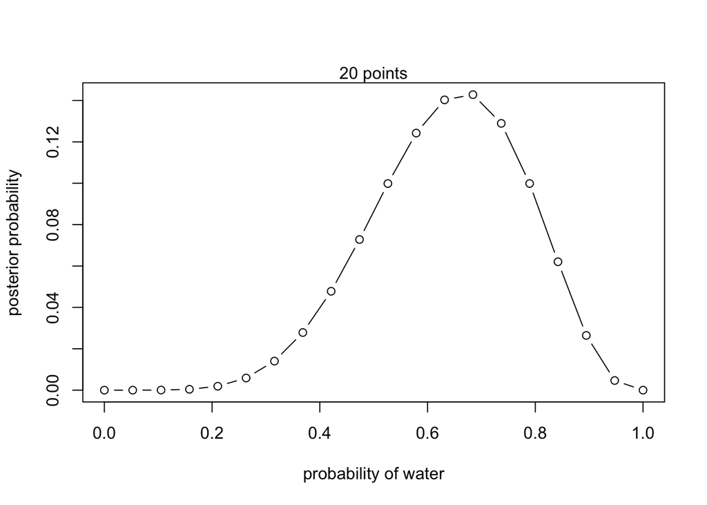

```r
## R code 2.4
plot( p_grid , posterior , type="b" ,
    xlab="probability of water" , ylab="posterior probability" )
mtext( "20 points" )
```

What happens if we alter the priors? What will be the new posteriors?

```r
## R code 2.5
prior <- ifelse( p_grid < 0.5 , 0 , 1 )
prior <- exp( -5*abs( p_grid - 0.5 ) )
```

### Bayesian Updating: Quadratic Approximation

```r
## R code 2.6
library(rethinking)
globe.qa <- quap(
    alist(
        W ~ dbinom( W+L ,p) ,  # binomial likelihood
        p ~ dunif(0,1)     # uniform prior
    ) ,
    data=list(W=6,L=3) )

# display summary of quadratic approximation
precis( globe.qa )
```

```r
##        mean        sd      5.5%     94.5%
## p 0.6666597 0.1571354 0.4155269 0.9177925
```

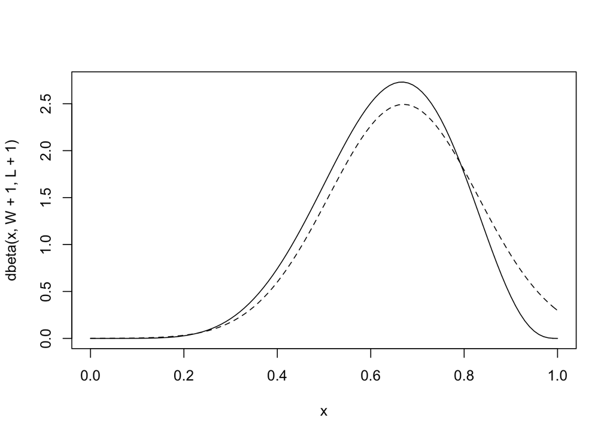

```r
## R code 2.7
# analytical calculation
W <- 6
L <- 3
curve( dbeta( x , W+1 , L+1 ) , from=0 , to=1 )
# quadratic approximation
curve( dnorm( x , 0.67 , 0.16 ) , lty=2 , add=TRUE )
```

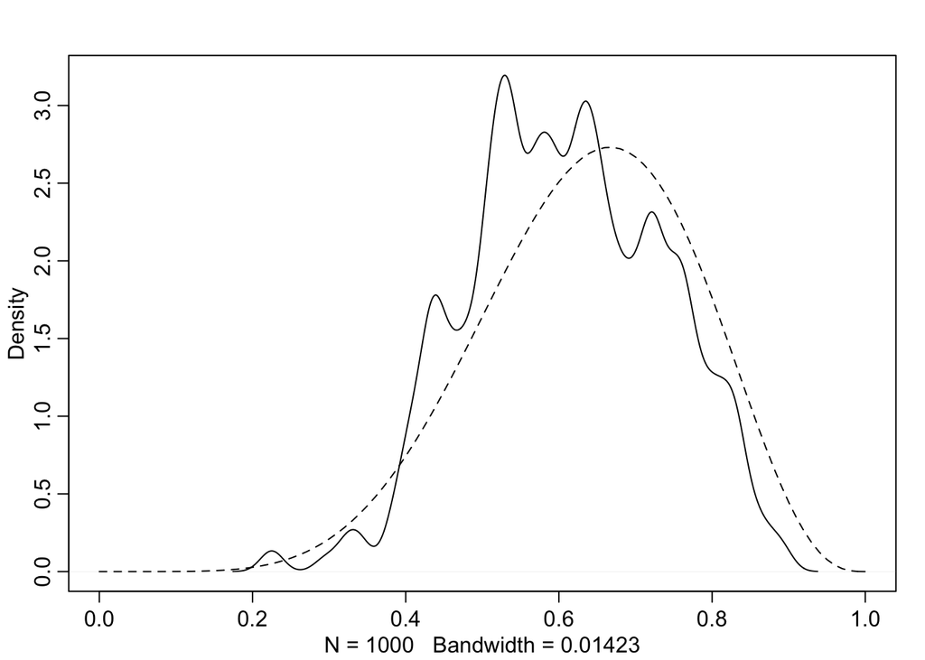

```r
## R code 2.8
n_samples <- 1000
p <- rep( NA , n_samples )
p[1] <- 0.5
W <- 6
L <- 3
for ( i in 2:n_samples ) {
    p_new <- rnorm( 1 , p[i-1] , 0.1 )
    if ( p_new < 0 ) p_new <- abs( p_new )
    if ( p_new > 1 ) p_new <- 2 - p_new
    q0 <- dbinom( W , W+L , p[i-1] )
    q1 <- dbinom( W , W+L , p_new )
    p[i] <- ifelse( runif(1) < q1/q0 , p_new , p[i-1] )
}

## R code 2.9
dens( p , xlim=c(0,1) )
curve( dbeta( x , W+1 , L+1 ) , lty=2 , add=TRUE )
```

### `tidyverse` conversion

Statistical Rethinking uses base R functions. More recently, Soloman Kurz has created a [translation of the book’s functions](https://bookdown.org/content/4857/) into `tidyverse` (and later `brms`) code. This is not necessary but could be extremely helpful to classmates who are familiar with `tidyverse` already.

First, we’ll need to call `tidyverse`. If you do not have `tidyverse`, you’ll need to install it.

```r
library(tidyverse)
```

For example, we can translate 2.3 code using pipes (`%>%`)

```r
d <- tibble(p_grid = seq(from = 0, to = 1, length.out = 20),      # define grid
           prior  = 1) %>%                                       # define prior
    mutate(likelihood = dbinom(6, size = 9, prob = p_grid)) %>%  # compute likelihood at each value in grid
    mutate(unstd_posterior = likelihood * prior) %>%             # compute product of likelihood and prior
    mutate(posterior = unstd_posterior / sum(unstd_posterior))

d
```

```r
## # A tibble: 20 × 5
##    p_grid prior likelihood unstd_posterior   posterior
##     <dbl> <dbl>      <dbl>           <dbl>       <dbl>
##  1 0          1 0               0          0
##  2 0.0526     1 0.00000152      0.00000152 0.000000799
##  3 0.105      1 0.0000819       0.0000819  0.0000431
##  4 0.158      1 0.000777        0.000777   0.000409
##  5 0.211      1 0.00360         0.00360    0.00189
##  6 0.263      1 0.0112          0.0112     0.00587
##  7 0.316      1 0.0267          0.0267     0.0140
##  8 0.368      1 0.0529          0.0529     0.0279
##  9 0.421      1 0.0908          0.0908     0.0478
## 10 0.474      1 0.138           0.138      0.0728
## 11 0.526      1 0.190           0.190      0.0999
## 12 0.579      1 0.236           0.236      0.124
## 13 0.632      1 0.267           0.267      0.140
## 14 0.684      1 0.271           0.271      0.143
## 15 0.737      1 0.245           0.245      0.129
## 16 0.789      1 0.190           0.190      0.0999
## 17 0.842      1 0.118           0.118      0.0621
## 18 0.895      1 0.0503          0.0503     0.0265
## 19 0.947      1 0.00885         0.00885    0.00466
## 20 1          1 0               0          0
```

With this calculated, we can then use `ggplot2`, the staple `ggplot2` data visualization package, to plot our posterior.

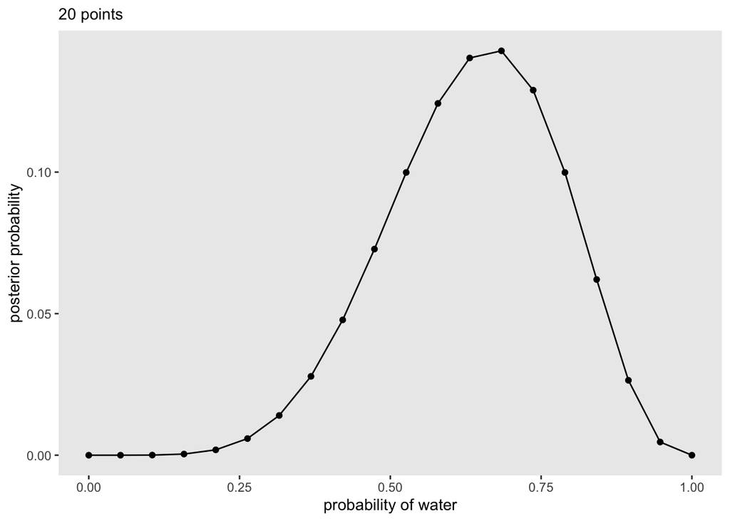

```r
d %>%
  ggplot(aes(x = p_grid, y = posterior)) +
  geom_point() +
  geom_line() +
  labs(subtitle = "20 points",
       x = "probability of water",
       y = "posterior probability") +
  theme(panel.grid = element_blank())
```

For this class, we’ll occasionally refer to Soloman’s guide.

## Package versions

```r
## R version 4.1.1 (2021-08-10)
## Platform: aarch64-apple-darwin20 (64-bit)
## Running under: macOS Monterey 12.0.1
##
## Matrix products: default
## BLAS:   /Library/Frameworks/R.framework/Versions/4.1-arm64/Resources/lib/libRblas.0.dylib
## LAPACK: /Library/Frameworks/R.framework/Versions/4.1-arm64/Resources/lib/libRlapack.dylib
##
## locale:
## [1] en_US.UTF-8/en_US.UTF-8/en_US.UTF-8/C/en_US.UTF-8/en_US.UTF-8
##
## attached base packages:
## [1] parallel  stats     graphics  grDevices utils     datasets  methods
## [8] base
##
## other attached packages:
##  [1] forcats_0.5.1        stringr_1.4.0        dplyr_1.0.7
##  [4] purrr_0.3.4          readr_2.0.2          tidyr_1.1.4
##  [7] tibble_3.1.6         tidyverse_1.3.1      rethinking_2.13
## [10] rstan_2.21.2         ggplot2_3.3.5        StanHeaders_2.21.0-7
##
## loaded via a namespace (and not attached):
##  [1] matrixStats_0.61.0  fs_1.5.0            lubridate_1.8.0
##  [4] httr_1.4.2          tools_4.1.1         backports_1.3.0
##  [7] bslib_0.3.1         utf8_1.2.2          R6_2.5.1
## [10] DBI_1.1.1           colorspace_2.0-2    withr_2.4.3
## [13] tidyselect_1.1.1    gridExtra_2.3       prettyunits_1.1.1
## [16] processx_3.5.2      curl_4.3.2          compiler_4.1.1
## [19] cli_3.1.0           rvest_1.0.2         xml2_1.3.2
## [22] labeling_0.4.2      sass_0.4.0          scales_1.1.1
## [25] mvtnorm_1.1-3       callr_3.7.0         bsplus_0.1.3
## [28] digest_0.6.29       rmarkdown_2.11      base64enc_0.1-3
## [31] pkgconfig_2.0.3     htmltools_0.5.2     dbplyr_2.1.1
## [34] fastmap_1.1.0       highr_0.9           rlang_0.4.12
## [37] readxl_1.3.1        rstudioapi_0.13     shape_1.4.6
## [40] jquerylib_0.1.4     generics_0.1.1      farver_2.1.0
## [43] jsonlite_1.7.2      inline_0.3.19       magrittr_2.0.1
## [46] loo_2.4.1           Rcpp_1.0.7          munsell_0.5.0
## [49] fansi_0.5.0         lifecycle_1.0.1     stringi_1.7.6
## [52] yaml_2.2.1          MASS_7.3-54         pkgbuild_1.3.0
## [55] grid_4.1.1          crayon_1.4.2        lattice_0.20-44
## [58] haven_2.4.3         hms_1.1.1           knitr_1.36
## [61] ps_1.6.0            pillar_1.6.4        uuid_1.0-3
## [64] codetools_0.2-18    stats4_4.1.1        reprex_2.0.1
## [67] glue_1.5.1          evaluate_0.14       V8_3.6.0
## [70] RcppParallel_5.1.4  modelr_0.1.8        vctrs_0.3.8
## [73] tzdb_0.1.2          cellranger_1.1.0    gtable_0.3.0
## [76] assertthat_0.2.1    xfun_0.28           mime_0.12
## [79] broom_0.7.9         coda_0.19-4         ellipsis_0.3.2
## [82] downloadthis_0.2.1  xaringanExtra_0.5.5
```